# Risk Factor Analysis

## Outcome Variable

**Outcome Variable:** ever_swasted

## Predictor Variables

**Intervention Variable:** mage

**Adjustment Set:**

- arm
- meducyrs
- feducyrs
- W_mhtcm
- W_mwtkg
- W_mbmi
- single
- delta_meducyrs
- delta_feducyrs
- delta_W_mhtcm
- delta_W_mwtkg
- delta_W_mbmi
- delta_single

## Stratifying Variables

The analysis was stratified on these variable(s):

- agecat
- studyid
- country

## Data Summary

| agecat | studyid | country | mage | ever_swasted | n_cell | n |
| --- | --- | --- | --- | --- | --- | --- |
| 0-24 months | CMC-V-BCS-2002 | INDIA | [20-30) | 0 | 222 | 373 |
| 0-24 months | CMC-V-BCS-2002 | INDIA | [20-30) | 1 | 74 | 373 |
| 0-24 months | CMC-V-BCS-2002 | INDIA | <20 | 0 | 27 | 373 |
| 0-24 months | CMC-V-BCS-2002 | INDIA | <20 | 1 | 7 | 373 |
| 0-24 months | CMC-V-BCS-2002 | INDIA | >=30 | 0 | 32 | 373 |
| 0-24 months | CMC-V-BCS-2002 | INDIA | >=30 | 1 | 11 | 373 |
| 0-24 months | COHORTS | GUATEMALA | [20-30) | 0 | 608 | 1341 |
| 0-24 months | COHORTS | GUATEMALA | [20-30) | 1 | 47 | 1341 |
| 0-24 months | COHORTS | GUATEMALA | <20 | 0 | 180 | 1341 |
| 0-24 months | COHORTS | GUATEMALA | <20 | 1 | 16 | 1341 |
| 0-24 months | COHORTS | GUATEMALA | >=30 | 0 | 456 | 1341 |
| 0-24 months | COHORTS | GUATEMALA | >=30 | 1 | 34 | 1341 |
| 0-24 months | COHORTS | INDIA | [20-30) | 0 | 3245 | 5305 |
| 0-24 months | COHORTS | INDIA | [20-30) | 1 | 352 | 5305 |
| 0-24 months | COHORTS | INDIA | <20 | 0 | 384 | 5305 |
| 0-24 months | COHORTS | INDIA | <20 | 1 | 42 | 5305 |
| 0-24 months | COHORTS | INDIA | >=30 | 0 | 1129 | 5305 |
| 0-24 months | COHORTS | INDIA | >=30 | 1 | 153 | 5305 |
| 0-24 months | COHORTS | PHILIPPINES | [20-30) | 0 | 1596 | 3045 |
| 0-24 months | COHORTS | PHILIPPINES | [20-30) | 1 | 224 | 3045 |
| 0-24 months | COHORTS | PHILIPPINES | <20 | 0 | 326 | 3045 |
| 0-24 months | COHORTS | PHILIPPINES | <20 | 1 | 51 | 3045 |
| 0-24 months | COHORTS | PHILIPPINES | >=30 | 0 | 741 | 3045 |
| 0-24 months | COHORTS | PHILIPPINES | >=30 | 1 | 107 | 3045 |
| 0-24 months | EE | PAKISTAN | [20-30) | 0 | 134 | 377 |
| 0-24 months | EE | PAKISTAN | [20-30) | 1 | 28 | 377 |
| 0-24 months | EE | PAKISTAN | <20 | 0 | 1 | 377 |
| 0-24 months | EE | PAKISTAN | <20 | 1 | 0 | 377 |
| 0-24 months | EE | PAKISTAN | >=30 | 0 | 163 | 377 |
| 0-24 months | EE | PAKISTAN | >=30 | 1 | 51 | 377 |

[output cut: 450 more lines]

The following strata were considered:

- agecat: 0-24 months, studyid: CMC-V-BCS-2002, country: INDIA
- agecat: 0-24 months, studyid: COHORTS, country: GUATEMALA
- agecat: 0-24 months, studyid: COHORTS, country: INDIA
- agecat: 0-24 months, studyid: COHORTS, country: PHILIPPINES
- agecat: 0-24 months, studyid: EE, country: PAKISTAN
- agecat: 0-24 months, studyid: GMS-Nepal, country: NEPAL
- agecat: 0-24 months, studyid: Guatemala BSC, country: GUATEMALA
- agecat: 0-24 months, studyid: iLiNS-Zinc, country: BURKINA FASO
- agecat: 0-24 months, studyid: IRC, country: INDIA
- agecat: 0-24 months, studyid: JiVitA-3, country: BANGLADESH
- agecat: 0-24 months, studyid: Keneba, country: GAMBIA
- agecat: 0-24 months, studyid: LCNI-5, country: MALAWI
- agecat: 0-24 months, studyid: MAL-ED, country: BANGLADESH
- agecat: 0-24 months, studyid: MAL-ED, country: BRAZIL
- agecat: 0-24 months, studyid: MAL-ED, country: INDIA
- agecat: 0-24 months, studyid: MAL-ED, country: NEPAL
- agecat: 0-24 months, studyid: MAL-ED, country: PERU
- agecat: 0-24 months, studyid: MAL-ED, country: SOUTH AFRICA
- agecat: 0-24 months, studyid: MAL-ED, country: TANZANIA, UNITED REPUBLIC OF
- agecat: 0-24 months, studyid: NIH-Birth, country: BANGLADESH
- agecat: 0-24 months, studyid: NIH-Crypto, country: BANGLADESH
- agecat: 0-24 months, studyid: PROBIT, country: BELARUS
- agecat: 0-24 months, studyid: PROVIDE, country: BANGLADESH
- agecat: 0-24 months, studyid: SAS-CompFeed, country: INDIA
- agecat: 0-24 months, studyid: SAS-FoodSuppl, country: INDIA
- agecat: 0-24 months, studyid: TanzaniaChild2, country: TANZANIA, UNITED REPUBLIC OF
- agecat: 0-24 months, studyid: ZVITAMBO, country: ZIMBABWE
- agecat: 0-6 months, studyid: CMC-V-BCS-2002, country: INDIA
- agecat: 0-6 months, studyid: COHORTS, country: GUATEMALA
- agecat: 0-6 months, studyid: COHORTS, country: INDIA
- agecat: 0-6 months, studyid: COHORTS, country: PHILIPPINES
- agecat: 0-6 months, studyid: EE, country: PAKISTAN
- agecat: 0-6 months, studyid: GMS-Nepal, country: NEPAL
- agecat: 0-6 months, studyid: Guatemala BSC, country: GUATEMALA
- agecat: 0-6 months, studyid: IRC, country: INDIA
- agecat: 0-6 months, studyid: JiVitA-3, country: BANGLADESH
- agecat: 0-6 months, studyid: Keneba, country: GAMBIA
- agecat: 0-6 months, studyid: LCNI-5, country: MALAWI
- agecat: 0-6 months, studyid: MAL-ED, country: BANGLADESH
- agecat: 0-6 months, studyid: MAL-ED, country: BRAZIL
- agecat: 0-6 months, studyid: MAL-ED, country: INDIA
- agecat: 0-6 months, studyid: MAL-ED, country: NEPAL
- agecat: 0-6 months, studyid: MAL-ED, country: PERU
- agecat: 0-6 months, studyid: MAL-ED, country: SOUTH AFRICA
- agecat: 0-6 months, studyid: MAL-ED, country: TANZANIA, UNITED REPUBLIC OF
- agecat: 0-6 months, studyid: NIH-Birth, country: BANGLADESH
- agecat: 0-6 months, studyid: NIH-Crypto, country: BANGLADESH
- agecat: 0-6 months, studyid: PROBIT, country: BELARUS
- agecat: 0-6 months, studyid: PROVIDE, country: BANGLADESH
- agecat: 0-6 months, studyid: SAS-CompFeed, country: INDIA
- agecat: 0-6 months, studyid: SAS-FoodSuppl, country: INDIA
- agecat: 0-6 months, studyid: TanzaniaChild2, country: TANZANIA, UNITED REPUBLIC OF
- agecat: 0-6 months, studyid: ZVITAMBO, country: ZIMBABWE
- agecat: 6-24 months, studyid: CMC-V-BCS-2002, country: INDIA
- agecat: 6-24 months, studyid: COHORTS, country: GUATEMALA
- agecat: 6-24 months, studyid: COHORTS, country: INDIA
- agecat: 6-24 months, studyid: COHORTS, country: PHILIPPINES
- agecat: 6-24 months, studyid: EE, country: PAKISTAN
- agecat: 6-24 months, studyid: GMS-Nepal, country: NEPAL
- agecat: 6-24 months, studyid: Guatemala BSC, country: GUATEMALA
- agecat: 6-24 months, studyid: iLiNS-Zinc, country: BURKINA FASO
- agecat: 6-24 months, studyid: IRC, country: INDIA
- agecat: 6-24 months, studyid: JiVitA-3, country: BANGLADESH
- agecat: 6-24 months, studyid: Keneba, country: GAMBIA
- agecat: 6-24 months, studyid: LCNI-5, country: MALAWI
- agecat: 6-24 months, studyid: MAL-ED, country: BANGLADESH
- agecat: 6-24 months, studyid: MAL-ED, country: BRAZIL
- agecat: 6-24 months, studyid: MAL-ED, country: INDIA
- agecat: 6-24 months, studyid: MAL-ED, country: NEPAL
- agecat: 6-24 months, studyid: MAL-ED, country: PERU
- agecat: 6-24 months, studyid: MAL-ED, country: SOUTH AFRICA
- agecat: 6-24 months, studyid: MAL-ED, country: TANZANIA, UNITED REPUBLIC OF
- agecat: 6-24 months, studyid: NIH-Birth, country: BANGLADESH
- agecat: 6-24 months, studyid: NIH-Crypto, country: BANGLADESH
- agecat: 6-24 months, studyid: PROBIT, country: BELARUS
- agecat: 6-24 months, studyid: PROVIDE, country: BANGLADESH
- agecat: 6-24 months, studyid: SAS-CompFeed, country: INDIA
- agecat: 6-24 months, studyid: SAS-FoodSuppl, country: INDIA
- agecat: 6-24 months, studyid: TanzaniaChild2, country: TANZANIA, UNITED REPUBLIC OF
- agecat: 6-24 months, studyid: ZVITAMBO, country: ZIMBABWE

### Dropped Strata

Some strata were dropped due to rare outcomes:

- agecat: 0-24 months, studyid: EE, country: PAKISTAN
- agecat: 0-24 months, studyid: Guatemala BSC, country: GUATEMALA
- agecat: 0-24 months, studyid: LCNI-5, country: MALAWI
- agecat: 0-24 months, studyid: MAL-ED, country: BANGLADESH
- agecat: 0-24 months, studyid: MAL-ED, country: BRAZIL
- agecat: 0-24 months, studyid: MAL-ED, country: INDIA
- agecat: 0-24 months, studyid: MAL-ED, country: NEPAL
- agecat: 0-24 months, studyid: MAL-ED, country: PERU
- agecat: 0-24 months, studyid: MAL-ED, country: SOUTH AFRICA
- agecat: 0-24 months, studyid: MAL-ED, country: TANZANIA, UNITED REPUBLIC OF
- agecat: 0-24 months, studyid: PROVIDE, country: BANGLADESH
- agecat: 0-24 months, studyid: SAS-FoodSuppl, country: INDIA
- agecat: 0-6 months, studyid: EE, country: PAKISTAN
- agecat: 0-6 months, studyid: Guatemala BSC, country: GUATEMALA
- agecat: 0-6 months, studyid: LCNI-5, country: MALAWI
- agecat: 0-6 months, studyid: MAL-ED, country: BANGLADESH
- agecat: 0-6 months, studyid: MAL-ED, country: BRAZIL
- agecat: 0-6 months, studyid: MAL-ED, country: INDIA
- agecat: 0-6 months, studyid: MAL-ED, country: NEPAL
- agecat: 0-6 months, studyid: MAL-ED, country: PERU
- agecat: 0-6 months, studyid: MAL-ED, country: SOUTH AFRICA
- agecat: 0-6 months, studyid: MAL-ED, country: TANZANIA, UNITED REPUBLIC OF
- agecat: 0-6 months, studyid: PROVIDE, country: BANGLADESH
- agecat: 0-6 months, studyid: SAS-FoodSuppl, country: INDIA
- agecat: 6-24 months, studyid: CMC-V-BCS-2002, country: INDIA
- agecat: 6-24 months, studyid: EE, country: PAKISTAN
- agecat: 6-24 months, studyid: Guatemala BSC, country: GUATEMALA
- agecat: 6-24 months, studyid: IRC, country: INDIA
- agecat: 6-24 months, studyid: LCNI-5, country: MALAWI
- agecat: 6-24 months, studyid: MAL-ED, country: BANGLADESH
- agecat: 6-24 months, studyid: MAL-ED, country: BRAZIL
- agecat: 6-24 months, studyid: MAL-ED, country: INDIA
- agecat: 6-24 months, studyid: MAL-ED, country: NEPAL
- agecat: 6-24 months, studyid: MAL-ED, country: PERU
- agecat: 6-24 months, studyid: MAL-ED, country: SOUTH AFRICA
- agecat: 6-24 months, studyid: MAL-ED, country: TANZANIA, UNITED REPUBLIC OF
- agecat: 6-24 months, studyid: NIH-Birth, country: BANGLADESH
- agecat: 6-24 months, studyid: NIH-Crypto, country: BANGLADESH
- agecat: 6-24 months, studyid: PROBIT, country: BELARUS
- agecat: 6-24 months, studyid: PROVIDE, country: BANGLADESH
- agecat: 6-24 months, studyid: SAS-FoodSuppl, country: INDIA

## Methods Detail

We’re interested in the causal parameters $E[Y_a]$ for all values of $a \in \mathcal{A}$. These parameters represent the mean outcome if, possibly contrary to fact, we intervened to set all units to have $A=a$. Under the randomization and positivity assumptions, these are identified by the statistical parameters $\psi_a=E_W[E_{Y|A,W}(Y|A=a,W)]$. In addition, we’re interested in the mean of $Y$, $E[Y]$ under no intervention (the observed mean). We will estimate these parameters by using SuperLearner to fit the relevant likelihood factors – $E_{Y|A,W}(Y|A=a,W)$ and $p(A=a|W)$, and then updating our likelihood fit using a joint TMLE.

For unadjusted analyses ($W=\{\}$), initial likelihoods were estimated using Lrnr_glm to estimate the simple $E(Y|A)$ and Lrnr_mean to estimate $p(A)$. For adjusted analyses, a small library containing Lrnr_glmnet, Lrnr_xgboost, and Lrnr_mean was used.

Having estimated these parameters, we will then use the delta method to estimate relative risks and attributable risks relative to a prespecified baseline level of $A$.

# Results Detail

## Results Plots

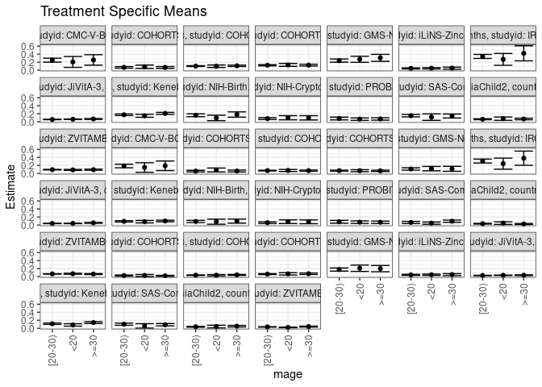

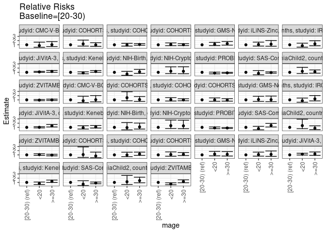

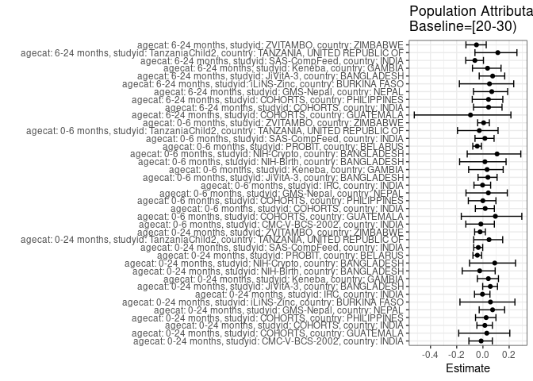

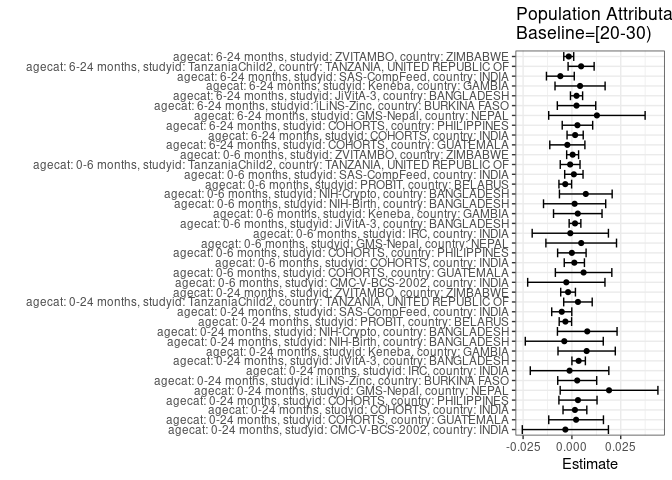

## Results Table

### Parameter: TSM

| agecat | studyid | country | intervention_level | baseline_level | estimate | ci_lower | ci_upper |
| --- | --- | --- | --- | --- | --- | --- | --- |
| 0-24 months | CMC-V-BCS-2002 | INDIA | [20-30) | NA | 0.2500000 | 0.2006047 | 0.2993953 |
| 0-24 months | CMC-V-BCS-2002 | INDIA | <20 | NA | 0.2058824 | 0.0697869 | 0.3419778 |
| 0-24 months | CMC-V-BCS-2002 | INDIA | >=30 | NA | 0.2558140 | 0.1252270 | 0.3864009 |
| 0-24 months | COHORTS | GUATEMALA | [20-30) | NA | 0.0701913 | 0.0507418 | 0.0896408 |
| 0-24 months | COHORTS | GUATEMALA | <20 | NA | 0.0856817 | 0.0447634 | 0.1266001 |
| 0-24 months | COHORTS | GUATEMALA | >=30 | NA | 0.0685542 | 0.0461130 | 0.0909954 |
| 0-24 months | COHORTS | INDIA | [20-30) | NA | 0.1015697 | 0.0914796 | 0.1116599 |
| 0-24 months | COHORTS | INDIA | <20 | NA | 0.0985837 | 0.0676113 | 0.1295560 |
| 0-24 months | COHORTS | INDIA | >=30 | NA | 0.1089340 | 0.0918378 | 0.1260303 |
| 0-24 months | COHORTS | PHILIPPINES | [20-30) | NA | 0.1223504 | 0.1072268 | 0.1374740 |
| 0-24 months | COHORTS | PHILIPPINES | <20 | NA | 0.1311710 | 0.0955793 | 0.1667628 |
| 0-24 months | COHORTS | PHILIPPINES | >=30 | NA | 0.1256269 | 0.1033032 | 0.1479505 |
| 0-24 months | GMS-Nepal | NEPAL | [20-30) | NA | 0.2389931 | 0.1990045 | 0.2789818 |
| 0-24 months | GMS-Nepal | NEPAL | <20 | NA | 0.2717297 | 0.1960983 | 0.3473611 |
| 0-24 months | GMS-Nepal | NEPAL | >=30 | NA | 0.3072095 | 0.2205714 | 0.3938477 |
| 0-24 months | iLiNS-Zinc | BURKINA FASO | [20-30) | NA | 0.0444695 | 0.0312197 | 0.0577193 |
| 0-24 months | iLiNS-Zinc | BURKINA FASO | <20 | NA | 0.0479148 | 0.0315359 | 0.0642936 |
| 0-24 months | iLiNS-Zinc | BURKINA FASO | >=30 | NA | 0.0512910 | 0.0255546 | 0.0770274 |
| 0-24 months | IRC | INDIA | [20-30) | NA | 0.3426698 | 0.2923746 | 0.3929650 |
| 0-24 months | IRC | INDIA | <20 | NA | 0.2691712 | 0.1216957 | 0.4166468 |
| 0-24 months | IRC | INDIA | >=30 | NA | 0.4206881 | 0.2332650 | 0.6081112 |
| 0-24 months | JiVitA-3 | BANGLADESH | [20-30) | NA | 0.0575646 | 0.0527704 | 0.0623588 |
| 0-24 months | JiVitA-3 | BANGLADESH | <20 | NA | 0.0633144 | 0.0579323 | 0.0686965 |
| 0-24 months | JiVitA-3 | BANGLADESH | >=30 | NA | 0.0693797 | 0.0580801 | 0.0806792 |
| 0-24 months | Keneba | GAMBIA | [20-30) | NA | 0.1747153 | 0.1545009 | 0.1949296 |
| 0-24 months | Keneba | GAMBIA | <20 | NA | 0.1498470 | 0.1127454 | 0.1869485 |
| 0-24 months | Keneba | GAMBIA | >=30 | NA | 0.2091545 | 0.1838035 | 0.2345055 |
| 0-24 months | NIH-Birth | BANGLADESH | [20-30) | NA | 0.1630695 | 0.1275833 | 0.1985558 |
| 0-24 months | NIH-Birth | BANGLADESH | <20 | NA | 0.0958904 | 0.0282924 | 0.1634885 |
| 0-24 months | NIH-Birth | BANGLADESH | >=30 | NA | 0.1818182 | 0.1159684 | 0.2476679 |

[output cut: 87 more lines]

### Parameter: E(Y)

| agecat | studyid | country | intervention_level | baseline_level | estimate | ci_lower | ci_upper |
| --- | --- | --- | --- | --- | --- | --- | --- |
| 0-24 months | CMC-V-BCS-2002 | INDIA | NA | NA | 0.2466488 | 0.2028447 | 0.2904529 |
| 0-24 months | COHORTS | GUATEMALA | NA | NA | 0.0723341 | 0.0584645 | 0.0862036 |
| 0-24 months | COHORTS | INDIA | NA | NA | 0.1031103 | 0.0949263 | 0.1112943 |
| 0-24 months | COHORTS | PHILIPPINES | NA | NA | 0.1254516 | 0.1136848 | 0.1372183 |
| 0-24 months | GMS-Nepal | NEPAL | NA | NA | 0.2580175 | 0.2252514 | 0.2907836 |
| 0-24 months | iLiNS-Zinc | BURKINA FASO | NA | NA | 0.0471846 | 0.0353428 | 0.0590265 |
| 0-24 months | IRC | INDIA | NA | NA | 0.3414634 | 0.2955068 | 0.3874201 |
| 0-24 months | JiVitA-3 | BANGLADESH | NA | NA | 0.0610132 | 0.0575333 | 0.0644930 |
| 0-24 months | Keneba | GAMBIA | NA | NA | 0.1822626 | 0.1681211 | 0.1964040 |
| 0-24 months | NIH-Birth | BANGLADESH | NA | NA | 0.1591640 | 0.1303913 | 0.1879367 |
| 0-24 months | NIH-Crypto | BANGLADESH | NA | NA | 0.0870712 | 0.0669870 | 0.1071555 |
| 0-24 months | PROBIT | BELARUS | NA | NA | 0.0784116 | 0.0458146 | 0.1110087 |
| 0-24 months | SAS-CompFeed | INDIA | NA | NA | 0.1473893 | 0.1184132 | 0.1763654 |
| 0-24 months | TanzaniaChild2 | TANZANIA, UNITED REPUBLIC OF | NA | NA | 0.0660774 | 0.0560867 | 0.0760682 |
| 0-24 months | ZVITAMBO | ZIMBABWE | NA | NA | 0.0919615 | 0.0871588 | 0.0967642 |
| 0-6 months | CMC-V-BCS-2002 | INDIA | NA | NA | 0.1820652 | 0.1425842 | 0.2215462 |
| 0-6 months | COHORTS | GUATEMALA | NA | NA | 0.0630292 | 0.0484135 | 0.0776449 |
| 0-6 months | COHORTS | INDIA | NA | NA | 0.0713446 | 0.0642809 | 0.0784082 |
| 0-6 months | COHORTS | PHILIPPINES | NA | NA | 0.0693167 | 0.0602923 | 0.0783411 |
| 0-6 months | GMS-Nepal | NEPAL | NA | NA | 0.1151603 | 0.0912555 | 0.1390652 |
| 0-6 months | IRC | INDIA | NA | NA | 0.3073171 | 0.2626027 | 0.3520314 |
| 0-6 months | JiVitA-3 | BANGLADESH | NA | NA | 0.0413811 | 0.0384001 | 0.0443621 |
| 0-6 months | Keneba | GAMBIA | NA | NA | 0.0945172 | 0.0829165 | 0.1061178 |
| 0-6 months | NIH-Birth | BANGLADESH | NA | NA | 0.0903226 | 0.0677415 | 0.1129037 |
| 0-6 months | NIH-Crypto | BANGLADESH | NA | NA | 0.0659631 | 0.0482810 | 0.0836451 |
| 0-6 months | PROBIT | BELARUS | NA | NA | 0.0777153 | 0.0450748 | 0.1103558 |
| 0-6 months | SAS-CompFeed | INDIA | NA | NA | 0.0664452 | 0.0425975 | 0.0902929 |
| 0-6 months | TanzaniaChild2 | TANZANIA, UNITED REPUBLIC OF | NA | NA | 0.0328283 | 0.0256620 | 0.0399945 |
| 0-6 months | ZVITAMBO | ZIMBABWE | NA | NA | 0.0685487 | 0.0643349 | 0.0727624 |
| 6-24 months | COHORTS | GUATEMALA | NA | NA | 0.0247321 | 0.0159885 | 0.0334756 |
| 6-24 months | COHORTS | INDIA | NA | NA | 0.0381279 | 0.0327962 | 0.0434596 |
| 6-24 months | COHORTS | PHILIPPINES | NA | NA | 0.0669277 | 0.0576848 | 0.0761707 |
| 6-24 months | GMS-Nepal | NEPAL | NA | NA | 0.1898305 | 0.1581595 | 0.2215015 |
| 6-24 months | iLiNS-Zinc | BURKINA FASO | NA | NA | 0.0471846 | 0.0353428 | 0.0590265 |
| 6-24 months | JiVitA-3 | BANGLADESH | NA | NA | 0.0319223 | 0.0290352 | 0.0348093 |
| 6-24 months | Keneba | GAMBIA | NA | NA | 0.1178877 | 0.1056970 | 0.1300784 |
| 6-24 months | SAS-CompFeed | INDIA | NA | NA | 0.0964723 | 0.0729872 | 0.1199573 |
| 6-24 months | TanzaniaChild2 | TANZANIA, UNITED REPUBLIC OF | NA | NA | 0.0414378 | 0.0327076 | 0.0501681 |
| 6-24 months | ZVITAMBO | ZIMBABWE | NA | NA | 0.0329039 | 0.0295377 | 0.0362701 |

### Parameter: RR

| agecat | studyid | country | intervention_level | baseline_level | estimate | ci_lower | ci_upper |
| --- | --- | --- | --- | --- | --- | --- | --- |
| 0-24 months | CMC-V-BCS-2002 | INDIA | [20-30) | [20-30) | 1.0000000 | 1.0000000 | 1.0000000 |
| 0-24 months | CMC-V-BCS-2002 | INDIA | <20 | [20-30) | 0.8235294 | 0.4130909 | 1.6417711 |
| 0-24 months | CMC-V-BCS-2002 | INDIA | >=30 | [20-30) | 1.0232558 | 0.5919164 | 1.7689196 |
| 0-24 months | COHORTS | GUATEMALA | [20-30) | [20-30) | 1.0000000 | 1.0000000 | 1.0000000 |
| 0-24 months | COHORTS | GUATEMALA | <20 | [20-30) | 1.2206880 | 0.7027878 | 2.1202405 |
| 0-24 months | COHORTS | GUATEMALA | >=30 | [20-30) | 0.9766760 | 0.6357961 | 1.5003177 |
| 0-24 months | COHORTS | INDIA | [20-30) | [20-30) | 1.0000000 | 1.0000000 | 1.0000000 |
| 0-24 months | COHORTS | INDIA | <20 | [20-30) | 0.9706011 | 0.6982301 | 1.3492208 |
| 0-24 months | COHORTS | INDIA | >=30 | [20-30) | 1.0725052 | 0.8909374 | 1.2910755 |
| 0-24 months | COHORTS | PHILIPPINES | [20-30) | [20-30) | 1.0000000 | 1.0000000 | 1.0000000 |
| 0-24 months | COHORTS | PHILIPPINES | <20 | [20-30) | 1.0720930 | 0.7957612 | 1.4443823 |
| 0-24 months | COHORTS | PHILIPPINES | >=30 | [20-30) | 1.0267790 | 0.8268524 | 1.2750463 |
| 0-24 months | GMS-Nepal | NEPAL | [20-30) | [20-30) | 1.0000000 | 1.0000000 | 1.0000000 |
| 0-24 months | GMS-Nepal | NEPAL | <20 | [20-30) | 1.1369771 | 0.8213594 | 1.5738747 |
| 0-24 months | GMS-Nepal | NEPAL | >=30 | [20-30) | 1.2854324 | 0.9263388 | 1.7837278 |
| 0-24 months | iLiNS-Zinc | BURKINA FASO | [20-30) | [20-30) | 1.0000000 | 1.0000000 | 1.0000000 |
| 0-24 months | iLiNS-Zinc | BURKINA FASO | <20 | [20-30) | 1.0774755 | 0.7053295 | 1.6459732 |
| 0-24 months | iLiNS-Zinc | BURKINA FASO | >=30 | [20-30) | 1.1533974 | 0.6622739 | 2.0087239 |
| 0-24 months | IRC | INDIA | [20-30) | [20-30) | 1.0000000 | 1.0000000 | 1.0000000 |
| 0-24 months | IRC | INDIA | <20 | [20-30) | 0.7855120 | 0.4454429 | 1.3852035 |
| 0-24 months | IRC | INDIA | >=30 | [20-30) | 1.2276778 | 0.7680464 | 1.9623721 |
| 0-24 months | JiVitA-3 | BANGLADESH | [20-30) | [20-30) | 1.0000000 | 1.0000000 | 1.0000000 |
| 0-24 months | JiVitA-3 | BANGLADESH | <20 | [20-30) | 1.0998839 | 0.9837342 | 1.2297474 |
| 0-24 months | JiVitA-3 | BANGLADESH | >=30 | [20-30) | 1.2052481 | 1.0101770 | 1.4379885 |
| 0-24 months | Keneba | GAMBIA | [20-30) | [20-30) | 1.0000000 | 1.0000000 | 1.0000000 |
| 0-24 months | Keneba | GAMBIA | <20 | [20-30) | 0.8576639 | 0.6527274 | 1.1269441 |
| 0-24 months | Keneba | GAMBIA | >=30 | [20-30) | 1.1971165 | 1.0124703 | 1.4154371 |
| 0-24 months | NIH-Birth | BANGLADESH | [20-30) | [20-30) | 1.0000000 | 1.0000000 | 1.0000000 |
| 0-24 months | NIH-Birth | BANGLADESH | <20 | [20-30) | 0.5880338 | 0.2811840 | 1.2297419 |
| 0-24 months | NIH-Birth | BANGLADESH | >=30 | [20-30) | 1.1149733 | 0.7307436 | 1.7012334 |

[output cut: 87 more lines]

### Parameter: PAR

| agecat | studyid | country | intervention_level | baseline_level | estimate | ci_lower | ci_upper |
| --- | --- | --- | --- | --- | --- | --- | --- |
| 0-24 months | CMC-V-BCS-2002 | INDIA | [20-30) | NA | -0.0033512 | -0.0254025 | 0.0187001 |
| 0-24 months | COHORTS | GUATEMALA | [20-30) | NA | 0.0021427 | -0.0118667 | 0.0161522 |
| 0-24 months | COHORTS | INDIA | [20-30) | NA | 0.0015406 | -0.0045526 | 0.0076337 |
| 0-24 months | COHORTS | PHILIPPINES | [20-30) | NA | 0.0031011 | -0.0066624 | 0.0128646 |
| 0-24 months | GMS-Nepal | NEPAL | [20-30) | NA | 0.0190244 | -0.0060003 | 0.0440491 |
| 0-24 months | iLiNS-Zinc | BURKINA FASO | [20-30) | NA | 0.0027152 | -0.0072656 | 0.0126959 |
| 0-24 months | IRC | INDIA | [20-30) | NA | -0.0012064 | -0.0213174 | 0.0189046 |
| 0-24 months | JiVitA-3 | BANGLADESH | [20-30) | NA | 0.0034486 | -0.0000014 | 0.0068985 |
| 0-24 months | Keneba | GAMBIA | [20-30) | NA | 0.0075473 | -0.0071273 | 0.0222220 |
| 0-24 months | NIH-Birth | BANGLADESH | [20-30) | NA | -0.0039056 | -0.0238720 | 0.0160609 |
| 0-24 months | NIH-Crypto | BANGLADESH | [20-30) | NA | 0.0078562 | -0.0074116 | 0.0231239 |
| 0-24 months | PROBIT | BELARUS | [20-30) | NA | -0.0033335 | -0.0065193 | -0.0001476 |
| 0-24 months | SAS-CompFeed | INDIA | [20-30) | NA | -0.0052031 | -0.0103458 | -0.0000604 |
| 0-24 months | TanzaniaChild2 | TANZANIA, UNITED REPUBLIC OF | [20-30) | NA | 0.0030930 | -0.0042076 | 0.0103936 |
| 0-24 months | ZVITAMBO | ZIMBABWE | [20-30) | NA | -0.0019672 | -0.0057383 | 0.0018040 |
| 0-6 months | CMC-V-BCS-2002 | INDIA | [20-30) | NA | -0.0028663 | -0.0226565 | 0.0169239 |
| 0-6 months | COHORTS | GUATEMALA | [20-30) | NA | 0.0059845 | -0.0084760 | 0.0204450 |
| 0-6 months | COHORTS | INDIA | [20-30) | NA | 0.0012413 | -0.0039266 | 0.0064092 |
| 0-6 months | COHORTS | PHILIPPINES | [20-30) | NA | -0.0000268 | -0.0073188 | 0.0072652 |
| 0-6 months | GMS-Nepal | NEPAL | [20-30) | NA | 0.0047594 | -0.0133282 | 0.0228470 |
| 0-6 months | IRC | INDIA | [20-30) | NA | -0.0008225 | -0.0203468 | 0.0187019 |
| 0-6 months | JiVitA-3 | BANGLADESH | [20-30) | NA | 0.0015831 | -0.0014171 | 0.0045834 |
| 0-6 months | Keneba | GAMBIA | [20-30) | NA | 0.0030048 | -0.0094150 | 0.0154245 |
| 0-6 months | NIH-Birth | BANGLADESH | [20-30) | NA | 0.0013803 | -0.0145456 | 0.0173061 |
| 0-6 months | NIH-Crypto | BANGLADESH | [20-30) | NA | 0.0071108 | -0.0063908 | 0.0206124 |
| 0-6 months | PROBIT | BELARUS | [20-30) | NA | -0.0033991 | -0.0066433 | -0.0001549 |
| 0-6 months | SAS-CompFeed | INDIA | [20-30) | NA | 0.0010002 | -0.0036966 | 0.0056969 |
| 0-6 months | TanzaniaChild2 | TANZANIA, UNITED REPUBLIC OF | [20-30) | NA | -0.0009082 | -0.0059724 | 0.0041560 |
| 0-6 months | ZVITAMBO | ZIMBABWE | [20-30) | NA | 0.0003707 | -0.0026841 | 0.0034256 |
| 6-24 months | COHORTS | GUATEMALA | [20-30) | NA | -0.0023407 | -0.0113312 | 0.0066498 |
| 6-24 months | COHORTS | INDIA | [20-30) | NA | 0.0016522 | -0.0024868 | 0.0057912 |
| 6-24 months | COHORTS | PHILIPPINES | [20-30) | NA | 0.0028362 | -0.0049639 | 0.0106363 |
| 6-24 months | GMS-Nepal | NEPAL | [20-30) | NA | 0.0128039 | -0.0118886 | 0.0374964 |
| 6-24 months | iLiNS-Zinc | BURKINA FASO | [20-30) | NA | 0.0023658 | -0.0074757 | 0.0122073 |
| 6-24 months | JiVitA-3 | BANGLADESH | [20-30) | NA | 0.0023676 | -0.0007475 | 0.0054827 |
| 6-24 months | Keneba | GAMBIA | [20-30) | NA | 0.0041722 | -0.0086580 | 0.0170023 |
| 6-24 months | SAS-CompFeed | INDIA | [20-30) | NA | -0.0059191 | -0.0130436 | 0.0012053 |
| 6-24 months | TanzaniaChild2 | TANZANIA, UNITED REPUBLIC OF | [20-30) | NA | 0.0047125 | -0.0019571 | 0.0113821 |
| 6-24 months | ZVITAMBO | ZIMBABWE | [20-30) | NA | -0.0016226 | -0.0041750 | 0.0009298 |

### Parameter: PAF

| agecat | studyid | country | intervention_level | baseline_level | estimate | ci_lower | ci_upper |
| --- | --- | --- | --- | --- | --- | --- | --- |
| 0-24 months | CMC-V-BCS-2002 | INDIA | [20-30) | NA | -0.0135870 | -0.1070401 | 0.0719771 |
| 0-24 months | COHORTS | GUATEMALA | [20-30) | NA | 0.0296229 | -0.1846525 | 0.2051410 |
| 0-24 months | COHORTS | INDIA | [20-30) | NA | 0.0149410 | -0.0459444 | 0.0722823 |
| 0-24 months | COHORTS | PHILIPPINES | [20-30) | NA | 0.0247197 | -0.0562788 | 0.0995070 |
| 0-24 months | GMS-Nepal | NEPAL | [20-30) | NA | 0.0737328 | -0.0283783 | 0.1657050 |
| 0-24 months | iLiNS-Zinc | BURKINA FASO | [20-30) | NA | 0.0575433 | -0.1752734 | 0.2442400 |
| 0-24 months | IRC | INDIA | [20-30) | NA | -0.0035330 | -0.0641907 | 0.0536672 |
| 0-24 months | JiVitA-3 | BANGLADESH | [20-30) | NA | 0.0565214 | -0.0017036 | 0.1113621 |
| 0-24 months | Keneba | GAMBIA | [20-30) | NA | 0.0414090 | -0.0425960 | 0.1186455 |
| 0-24 months | NIH-Birth | BANGLADESH | [20-30) | NA | -0.0245379 | -0.1579328 | 0.0934897 |
| 0-24 months | NIH-Crypto | BANGLADESH | [20-30) | NA | 0.0902268 | -0.1019681 | 0.2489010 |
| 0-24 months | PROBIT | BELARUS | [20-30) | NA | -0.0425125 | -0.0760412 | -0.0100285 |
| 0-24 months | SAS-CompFeed | INDIA | [20-30) | NA | -0.0353018 | -0.0700598 | -0.0016727 |
| 0-24 months | TanzaniaChild2 | TANZANIA, UNITED REPUBLIC OF | [20-30) | NA | 0.0468087 | -0.0701271 | 0.1509666 |
| 0-24 months | ZVITAMBO | ZIMBABWE | [20-30) | NA | -0.0213912 | -0.0632106 | 0.0187834 |
| 0-6 months | CMC-V-BCS-2002 | INDIA | [20-30) | NA | -0.0157432 | -0.1304383 | 0.0873149 |
| 0-6 months | COHORTS | GUATEMALA | [20-30) | NA | 0.0949486 | -0.1650371 | 0.2969168 |
| 0-6 months | COHORTS | INDIA | [20-30) | NA | 0.0173987 | -0.0577526 | 0.0872108 |
| 0-6 months | COHORTS | PHILIPPINES | [20-30) | NA | -0.0003867 | -0.1113152 | 0.0994691 |
| 0-6 months | GMS-Nepal | NEPAL | [20-30) | NA | 0.0413285 | -0.1291765 | 0.1860874 |
| 0-6 months | IRC | INDIA | [20-30) | NA | -0.0026763 | -0.0682637 | 0.0588843 |
| 0-6 months | JiVitA-3 | BANGLADESH | [20-30) | NA | 0.0382575 | -0.0371275 | 0.1081630 |
| 0-6 months | Keneba | GAMBIA | [20-30) | NA | 0.0317905 | -0.1089311 | 0.1546548 |
| 0-6 months | NIH-Birth | BANGLADESH | [20-30) | NA | 0.0152816 | -0.1777722 | 0.1766911 |
| 0-6 months | NIH-Crypto | BANGLADESH | [20-30) | NA | 0.1077995 | -0.1198682 | 0.2891826 |
| 0-6 months | PROBIT | BELARUS | [20-30) | NA | -0.0437380 | -0.0773126 | -0.0112098 |
| 0-6 months | SAS-CompFeed | INDIA | [20-30) | NA | 0.0150524 | -0.0603904 | 0.0851277 |
| 0-6 months | TanzaniaChild2 | TANZANIA, UNITED REPUBLIC OF | [20-30) | NA | -0.0276649 | -0.1939816 | 0.1154846 |
| 0-6 months | ZVITAMBO | ZIMBABWE | [20-30) | NA | 0.0054082 | -0.0401708 | 0.0489899 |
| 6-24 months | COHORTS | GUATEMALA | [20-30) | NA | -0.0946418 | -0.5237626 | 0.2136303 |
| 6-24 months | COHORTS | INDIA | [20-30) | NA | 0.0433335 | -0.0714731 | 0.1458387 |
| 6-24 months | COHORTS | PHILIPPINES | [20-30) | NA | 0.0423768 | -0.0813919 | 0.1519797 |
| 6-24 months | GMS-Nepal | NEPAL | [20-30) | NA | 0.0674492 | -0.0719333 | 0.1887079 |
| 6-24 months | iLiNS-Zinc | BURKINA FASO | [20-30) | NA | 0.0501382 | -0.1795255 | 0.2350843 |
| 6-24 months | JiVitA-3 | BANGLADESH | [20-30) | NA | 0.0741688 | -0.0283075 | 0.1664328 |
| 6-24 months | Keneba | GAMBIA | [20-30) | NA | 0.0353912 | -0.0798288 | 0.1383169 |
| 6-24 months | SAS-CompFeed | INDIA | [20-30) | NA | -0.0613559 | -0.1311858 | 0.0041632 |
| 6-24 months | TanzaniaChild2 | TANZANIA, UNITED REPUBLIC OF | [20-30) | NA | 0.1137250 | -0.0607877 | 0.2595282 |
| 6-24 months | ZVITAMBO | ZIMBABWE | [20-30) | NA | -0.0493144 | -0.1295947 | 0.0252604 |